# World Climate Change

02/09/2021

## Introduzione

Lo scopo dello studio è quello di analizzare la variazione di temperatura media dei paesi dall’anno 1860 al 2012 allo scopo di valutare l’intensità del cambiamento climatico sul nostro pianeta dall’inizio della seconda rivoluzione industriale. Il dataset utilizzato per lo studio si chiama *Climate Change: Earth Surface Temperature Data* reperibile all’indirizzo [World Temperature Data](https://www.kaggle.com/berkeleyearth/climate-change-earth-surface-temperature-data).

## Dataset

Il dataset è strutturato in 4 colonne contententi nell’ordine la data di rilevazione della temperatura, la temperatura media rilevata, l’incertezza di misurazione ed infine il Paese nel quale è stata effettuata la rilevazione alle quali poi sono state aggiunte ulteriori colonne utili per i successivi studi.

Dataset:

```
# A tibble: 6 x 8
   Year Month AverageTemperatu~ AverageTemperat~ Country season iso_a3 continent
  <dbl> <dbl>             <dbl>            <dbl> <chr>   <chr>  <chr>  <chr>
1  1743    11              4.38             2.29 Åland ~ Autumn ALA    Europe
2  1744     4              1.53             4.68 Åland ~ Spring ALA    Europe
3  1744     5              6.70             1.79 Åland ~ Spring ALA    Europe
4  1744     6             11.6              1.58 Åland ~ Spring ALA    Europe
5  1744     7             15.3              1.41 Åland ~ Summer ALA    Europe
6  1744     9             11.7              1.52 Åland ~ Summer ALA    Europe
```

## Temperature medie attuali nei vari stati del mondo nel periodo 2002-2012

Temperatura media attuale del pianeta (°C):

[output not shown]

Mappa temperature medie nel mondo

[interactive chart not shown]

## Temperature medie attuali nelle varie stagioni

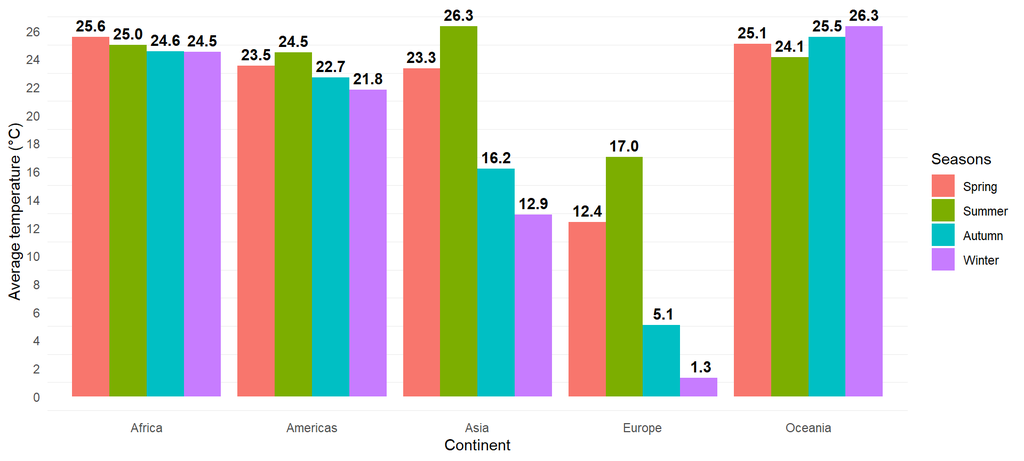

Temperature medie attuali nei vari continenti durante l’anno

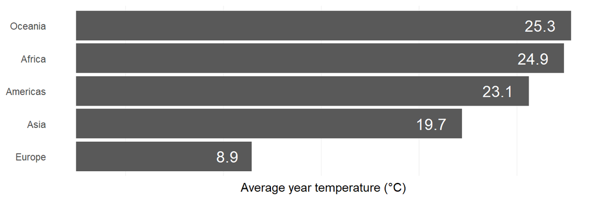

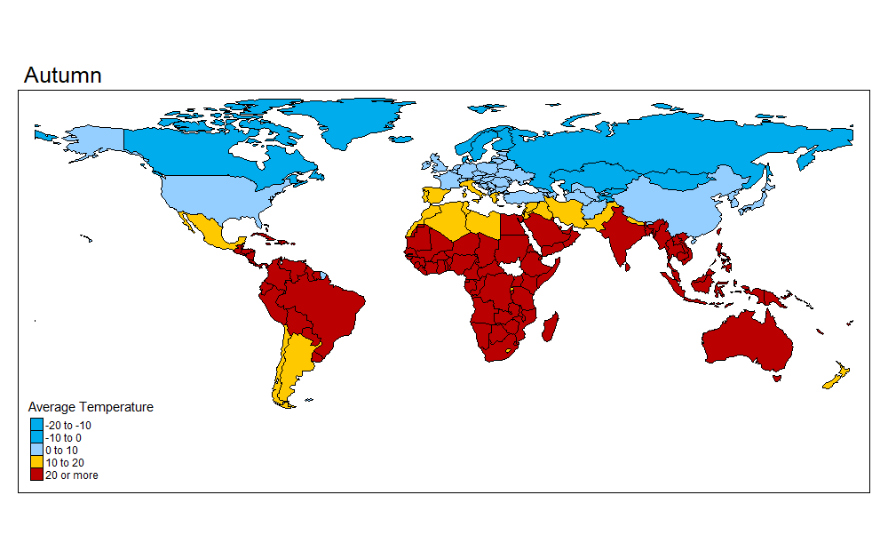

## Variazione della temperatura media del pianeta tra il 1860 e il 2012

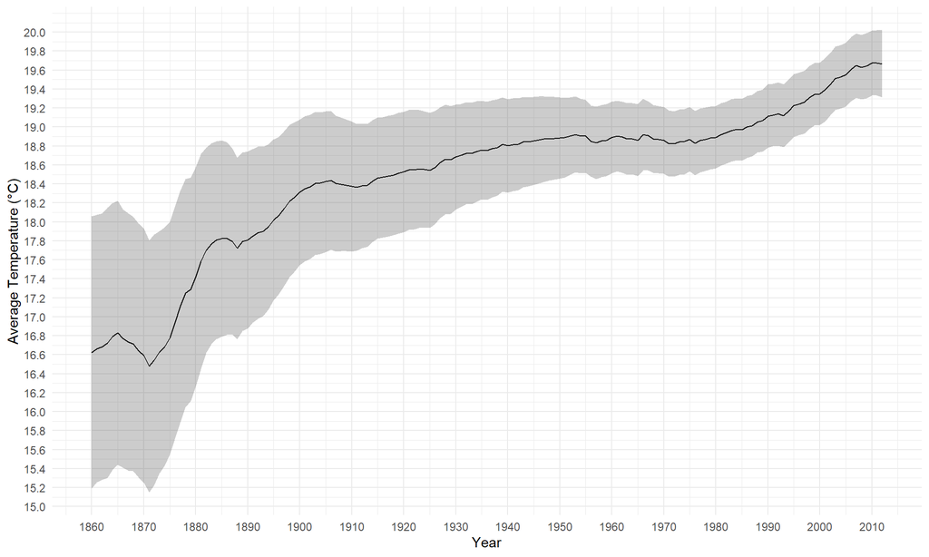

Animazione della variazione di temperatura nel periodo 1860-2012

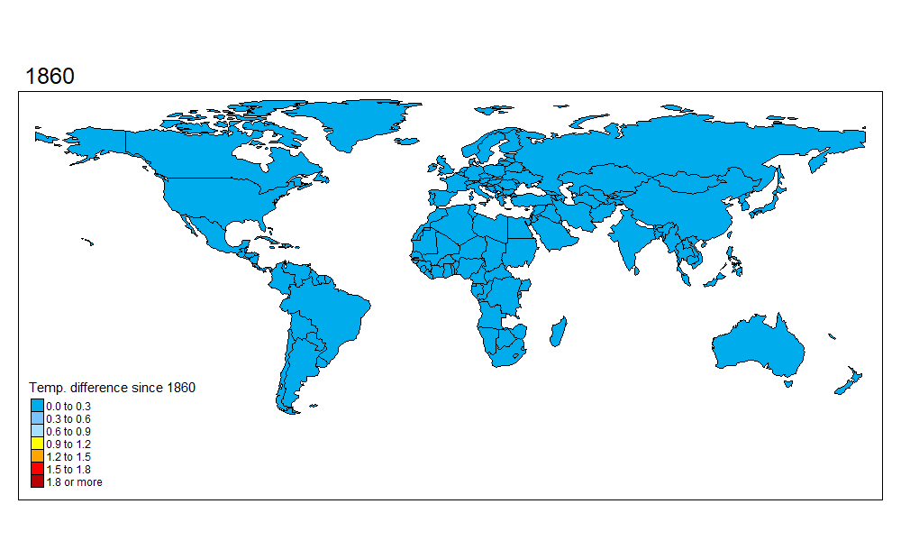

Dal grafico si può notare che effettivamente in media la temperatura è costantemente aumentata nel periodo analizzato con una variazione nella media di circa 3°C (+18%) ai giorni nostri rispetto al 1860.

**Temperatura media periodo 1850-1860 e 2002-2012:**

```
# A tibble: 2 x 2
   Year AverageTemperature
  <dbl>              <dbl>
1  1860               16.6
2  2012               19.7
```

**Variazione assoluta temperatura in °C:**

```
[1] 3.043015
```

**Variazione percentuale temperatura:**

```
[1] 18.30516
```

L’aumento più vertigionoso si nota successivamente al 1870, periodo di piena rivoluzione industriale e tra il 1970-2010, anni in cui la produzione di energia proveniente da combustibili fossili è aumentata del 140%, le emissioni dei trasporti sono aumentate del 120% e le emissioni delle industrie del 65% ([Fonte](https://www.ipcc.ch/site/assets/uploads/2021/03/ar4-wg3-spm-1.pdf)).

## Variazione della temperatura media nelle varie stagioni

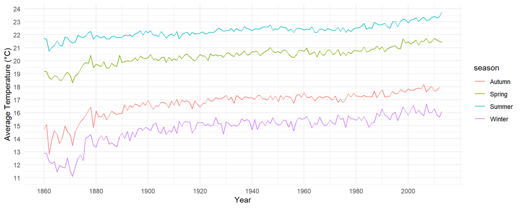

## Variazione della temperatura media nei vari stati

[figure not shown]

## Mappa della variazione di temperatura fra il 1860 e il 2012

[interactive chart not shown]

## Emissioni di CO2 nel periodo 1860-2012

Dataset utilizzato: [World CO2 Emissions](https://www.kaggle.com/srikantsahu/co2-and-ghg-emission-data).

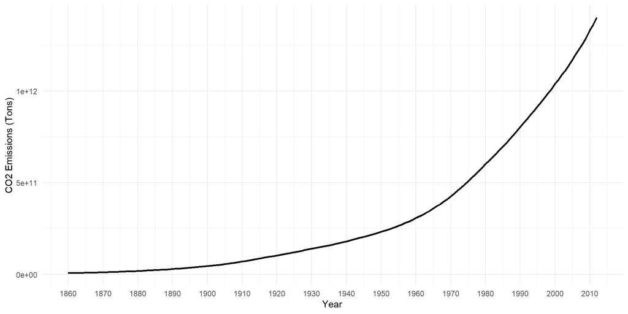

Aumento della produzione di CO2 nel mondo dal 1860 al 2012 in tonnellate:

```
# A tibble: 2 x 2
  Year  AverageEmissions
  <fct> <chr>
1 1860  "   5952413821"
2 2012  "1234545454545"
```

Aumento della produzione di CO2 nel mondo dal 1860 al 2012 in percentuale:

```
[1] 20640.25
```

I primi 10 stati per quantità di CO2 prodotta dal 1860 al 2012

```
# A tibble: 10 x 3
   Country        AverageEmissions em_rank
   <chr>                     <dbl>   <int>
 1 United States       66446985866       1
 2 United Kingdom      22194820841       2
 3 Germany             18821649135       3
 4 China               12752297532       4
 5 Russia              10861462734       5
 6 France               7884986297       6
 7 Japan                6953237331       7
 8 Poland               4600368871       8
 9 Canada               4336122522       9
10 India                3723461416      10
```

Correlazione tra aumento di emissione di CO2 e aumento di Temperatura del pianeta:

```
    Pearson's product-moment correlation

data:  emissions_vs_temp$Emissions and emissions_vs_temp$AverageTemperature
t = 12.731, df = 151, p-value < 2.2e-16
alternative hypothesis: true correlation is not equal to 0
95 percent confidence interval:
 0.6331118 0.7881971
sample estimates:
      cor
0.7195075
```

## I Paesi con la maggior crescita di temperatura sono quelli che inquinano di più?

## NO!

Correlazione tra emissione di CO2 e aumento di temperatura nel Paese di emissione:

```
    Pearson's product-moment correlation

data:  emissions_vs_temp_country$diff_temp and emissions_vs_temp_country$total_emissions_1970_2012
t = 0.22383, df = 168, p-value = 0.8232
alternative hypothesis: true correlation is not equal to 0
95 percent confidence interval:
 -0.1335952  0.1673456
sample estimates:
      cor
0.0172662
```

Tabella di confronto emissioni/rank nei vari paesi

```
# A tibble: 10 x 6
# Groups:   Country [10]
   Country  av_temp_1850_18~ av_temp_2002_20~ diff_temp AverageEmissions em_rank
   <chr>               <dbl>            <dbl>     <dbl>            <dbl>   <int>
 1 Greenla~           -19.0           -16.8        2.23          3265094     160
 2 United ~            27.1            29.1        2.05        245215483      57
 3 Mongolia            -1.48            0.527      2.01         38194303      97
 4 Russia              -5.95           -3.95       2         10861462734       5
 5 Canada              -5.58           -3.64       1.94       4336122522       9
 6 Iran                17.2            19.1        1.92       1335431440      20
 7 Qatar               26.3            28.2        1.92        103843421      75
 8 Oman                26.3            28.2        1.91         53425719      89
 9 Denmark             -5.51           -3.60       1.9         637505959      34
10 Bahrain             25.4            27.3        1.87         66165100      85
```

## Conclusioni

- L’aumento di temperatura rispetto al 1860 è considerevole ed è di circa 3° (+18%)
- L’aumento di temperatura è strettamente correlato all’aumento di produzione di CO2 da parte delle industrie (aumentato di 200 volte negli ultimi 160 anni)
- L’aumento di temperatura non è uniforme tra i paesi e l’aumento di temperatura in un paese non è strettamente correlato alla quantità di CO2 che produce